# Do Industries Explain Momentum? A Replication of Moskowitz and Grinblatt 2004

The following data table sumarized the results of our price based extension.

```
##                                      1,1          6,6
## Individual Stock-High Price -0.010594849  0.008840624
## Industry-High Price          0.016173574  0.017513019
## Individual Stock-Low Price   0.003816378  0.014440227
## Industry-Low Price           0.010761245  0.034330026
```

The following graphs show the cumulative returns over our aprox 120 month period of our Industry (1,1) portfolio, our industry (6,6) portfolio, our stock (1,1) portfolio, and our stock (6,6) portfoli.

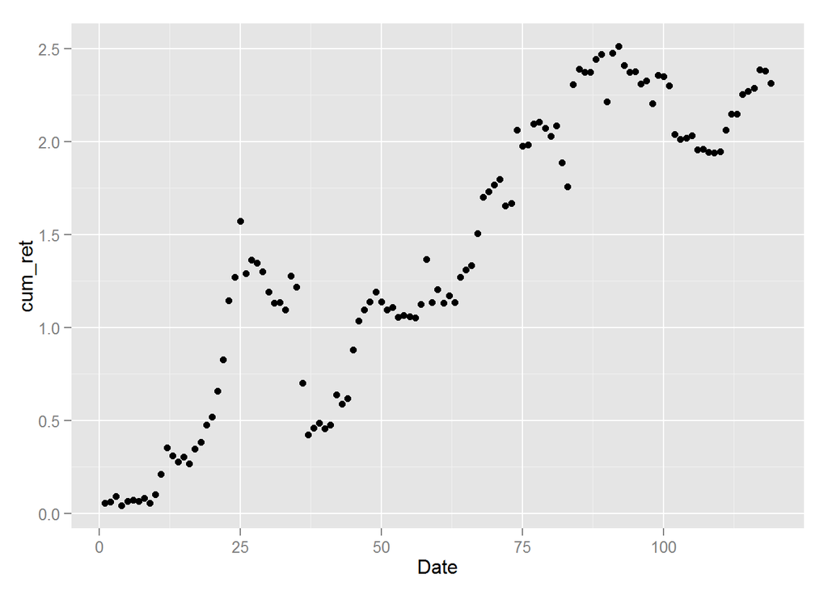

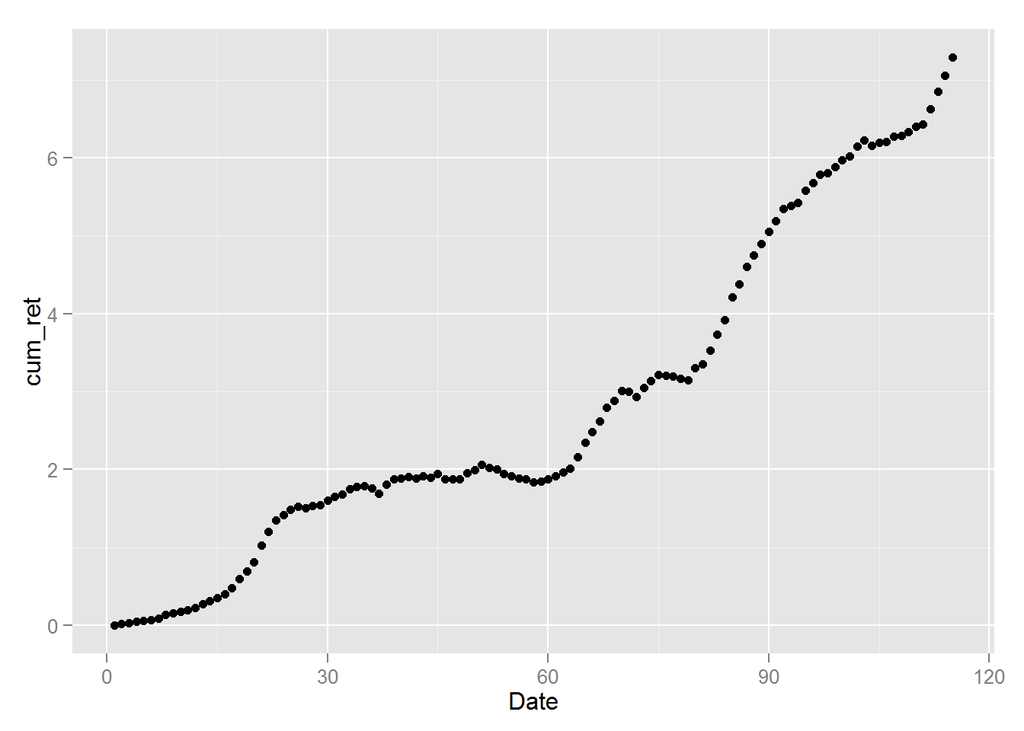

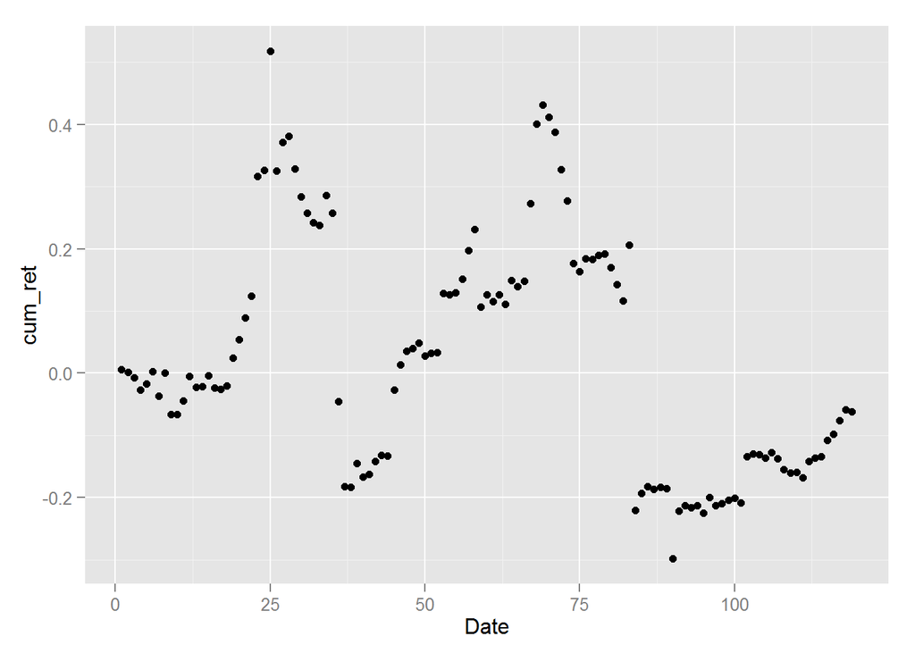

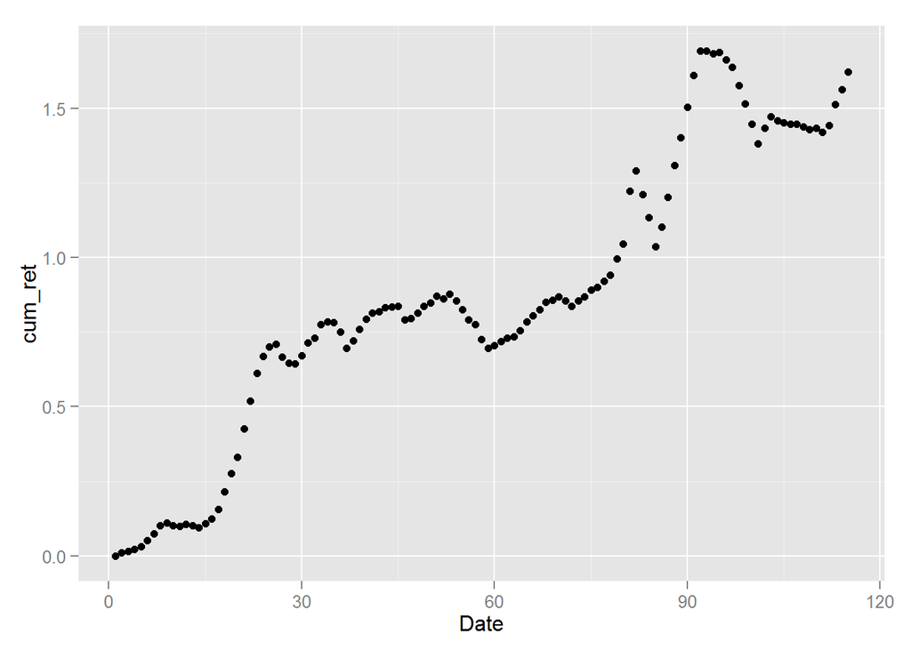

Conclusion In the past researchers have identified a link between the past performance of stocks and their future performance in the short and intermediate terms, deemed the “momentum effect”. Moskowitz and Grinblatt extended that analysis by identifying a momentum effect for industries as a whole and concluded that the industries momentum accounted for a large proportion of the profits realized by individual stock momentum. We analysed 3083 large cap stocks from 1998 to 2007 that during at least one year were in the top 1500 stocks by market cap. We initially created four portfolios by taking the top 30% by mean return for the past month, and then for the past six months, for both stocks and industries. We would then hold those portfolios for one and six months respectively and created new portfolios each month. In both the (1,1) and (6,6) time frames the industry momentum strategy returned substantialy more, with the (1,1) individual stock’s returns at almost 0. We concluded that the momentum effect is a stronger explanation than individual stock momentum, and that both strategies perform better using the (6,6) time frame. As an extension to MG’s paper we decided to study the effect of equity price as well as momentum. To do this we separated stocks and industries into high and low price buckets (30%) based on each stocks first recorded price. We than ran each bucket, Stock/High, Stock/Low, Ind/High, Ind/Low through the (1,1) and (6,6) strategies. For every bucket the (6,6) time frame provided higher returns, and industries always out performed stocks in the same price level. Interestingly the low priced bucket actully out performed the high price buckets for (1,1) stocks and both (6,6) industries and stocks. We hypothesize that this is due to survivorship bias introduced by our methods and data set that must be corrected for in future studies. In summary, Industry and (6,6) always produce higher returns in our study but their is insuficient evidence to pronounce final jugement on the effect of price in our model.